# TCC - Modelo T2 (Análise Exploratória) - ENEM

Adriana Melges Q Weingart

Setembro 2022

# 1 Análise Exploratória: Dados do ENEM 2020

## 1.1 Dataset

Microdados do ENEM 2020, disponíveis na página do [Ministério da Educação - Instituto Nacional de Estudos e Pesquisas Educacionais Anísio Teixeira | Inep - ENEM](https://www.gov.br/inep/pt-br/acesso-a-informacao/dados-abertos/microdados/enem).

## 1.2 Bibliotecas

```r
library(tidyverse)
library(stringi)
library(gridExtra)
library(psych)
library(kableExtra)
library(tictoc)
library(knitr)
```

## 1.3 Loading Data

Carregando o dataset de Microdados do Enem de 2020 Dataset: ENEM2020

```r
ENEM2020 <- read_delim("MICRODADOS_ENEM_2020.csv", delim = ";")
```

## 1.4 Cleaning Data

### 1.4.1 Reduzindo o Dataset

**Objetivo:** otimizar o processamento e análise, mantendo apenas as variáveis de interesse

```r
ENEM <- ENEM2020[ , c(
        "NU_INSCRICAO",       # Número de inscrição
        "TP_SEXO",            # Categórica - Sexo
        "TP_ESCOLA",          # Categórica - Tipo de escola do Ensino Médio
        "SG_UF_PROVA",        # Categórica - Sigla da Unidade da Federação da aplicação da prova
        "TP_PRESENCA_CN",     # Categórica - Presença na prova objetiva de Ciências da Natureza
        "TP_PRESENCA_CH",     # Categórica - Presença na prova objetiva de Ciências Humanas
        "TP_PRESENCA_LC",     # Categórica - Presença na prova objetiva de Linguagens e Códigos
        "TP_PRESENCA_MT",     # Categórica - Presença na prova objetiva de Matemática
        "NU_NOTA_CN",         # Numérica - Nota da prova de Ciências da Natureza
        "NU_NOTA_CH",         # Numérica - Nota da prova de Ciências Humanas
        "NU_NOTA_LC",         # Numérica - Nota da prova de Linguagens e Códigos
        "NU_NOTA_MT",         # Numérica - Nota da prova de Matemática
        "TP_STATUS_REDACAO",  # Categórica - Situação da redação do participante
        "NU_NOTA_REDACAO")]   # Numérica - Nota da prova de redação

ENEM <- ENEM %>%
  rename(ciencias_natureza = NU_NOTA_CH,
         ciencias_humanas = NU_NOTA_CH,
         linguagens_codigos = NU_NOTA_LC,
         matematica = NU_NOTA_MT,
         redacao = NU_NOTA_REDACAO)
```

Essa etapa realiza 2 ações:  
1. Reduzir o número de variáveis do DataSet de 76 para 14;  
2. Renomear as variáveis de notas para nomes mais claros para leitura.

### 1.4.2 Verificando NAs no dataset

```r
colSums(is.na(ENEM))
```

```
##       NU_INSCRICAO            TP_SEXO          TP_ESCOLA        SG_UF_PROVA
##                  0                  0                  0                  0
##     TP_PRESENCA_CN     TP_PRESENCA_CH     TP_PRESENCA_LC     TP_PRESENCA_MT
##                  0                  0                  0                  0
##         NU_NOTA_CN   ciencias_humanas linguagens_codigos         matematica
##            3185669            3028969            3028969            3185669
##  TP_STATUS_REDACAO            redacao
##            3028969            3028969
```

### 1.4.3 Removendo as entradas dos participantes que faltaram alguma das provas

```r
ENEM[ENEM$TP_PRESENCA_CN == '1' &
     ENEM$TP_PRESENCA_CH == '1' &
     ENEM$TP_PRESENCA_LC == '1' &
     ENEM$TP_PRESENCA_MT == '1', ] -> ENEM
```

**Comentário:**

Muitos NAs estão nas notas dos participantes.

As variáveis NU_NOTA_CN, NU_NOTA_CH, NU_NOTA_LC e NU_NOTA_MT são as notas dos participantes nas provas. NA nestes campos indicam: faltou à prova (0) ou foi eliminado na prova (2) - valores das variáveis TP_PRESENÇA_xx.

Para evitar NA nas notas (participantes faltaram ou foram eliminados), considerando apenas as observações com TP_PRESENÇA_xx = 1 (presente na prova).

Novo Dataframe criado: ENEM_presents, com apenas os presentes nas provas.

```r
ENEM %>% filter(TP_PRESENCA_CN == "1" &
                TP_PRESENCA_CH == "1" &
                TP_PRESENCA_LC == "1" &
                TP_PRESENCA_MT == "1") -> ENEM_presents
```

Com a remoção dos NAs (participantes que faltaram ou que foram desclassificados), o dataset passou de 2588681 observações para 2588681 observações.

Verificação de NAs no dataset, após a remoção dos ausentes e eliminados.  
Dataset usado: ENEM_presents

### 1.4.4 Verificando NAs no dataset

```r
colSums(is.na(ENEM_presents))
```

```
##       NU_INSCRICAO            TP_SEXO          TP_ESCOLA        SG_UF_PROVA
##                  0                  0                  0                  0
##     TP_PRESENCA_CN     TP_PRESENCA_CH     TP_PRESENCA_LC     TP_PRESENCA_MT
##                  0                  0                  0                  0
##         NU_NOTA_CN   ciencias_humanas linguagens_codigos         matematica
##                  0                  0                  0                  0
##  TP_STATUS_REDACAO            redacao
##                  0                  0
```

Não há mais NAs no dataset ENEM_presents.

### 1.4.5 Substituindo valores originais do dataset oficial por valores mais claros

**Tipo de Escola**

| valor original | Novo valor |
| --- | --- |
| 1 | não respondeu |
| 2 | pública |
| 3 | privada |
| 4 | exterior |

> Uso de pacote *stringi*

## 1.5 Análise Exploratória

### 1.5.1 Distribuição de participantes por Estados

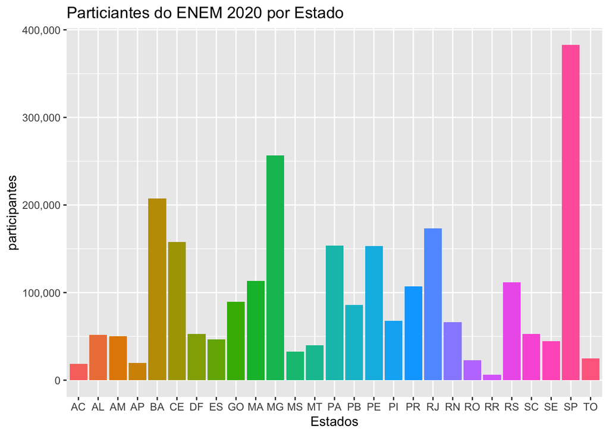

```r
ENEM_presents %>%
  ggplot() +
  geom_bar(aes(x = SG_UF_PROVA, fill = SG_UF_PROVA)) +
  labs(title = "Particiantes do ENEM 2020 por Estado",
       x = "Estados",
       y = "participantes") +
  theme(legend.position = "none") +
  scale_y_continuous(labels = scales::comma)
```

```r
#  geom_label(aes(x = SG_UF_PROVA, label = ..count..),
#             stat = "count", vjust = 0.5) +
```

**Comentário:** Pode-se observar que o Estado com mais participantes nesta edição do ENEM foi SP (com 382903 participantes); e o Estado com menos participantes foi RR (com 6199).

### 1.5.2 Provas de Redação e Matemática

#### 1.5.2.1 Desempenho dos alunos nas provas

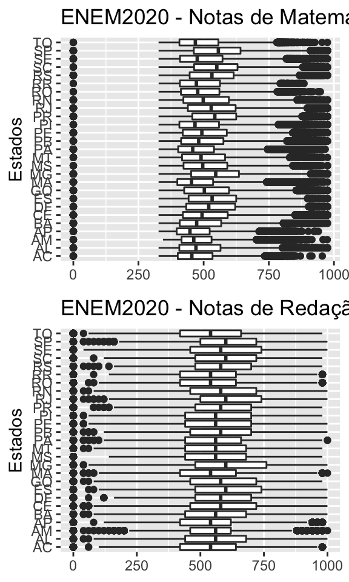

```r
estados_mat <- ggplot(ENEM_presents, aes(x=SG_UF_PROVA, y=matematica)) +
  geom_boxplot() +
  labs(title = "ENEM2020 - Notas de Matemática",
       x = "Estados",
       y = NULL) +
    coord_flip()

estados_red <- ggplot(ENEM_presents, aes(x=SG_UF_PROVA, y=redacao)) +
  geom_boxplot() +
  labs(title = "ENEM2020 - Notas de Redação",
       x = "Estados",
       y = NULL) +
    coord_flip()

grid.arrange(estados_mat, estados_red, ncol = 1)
```

**Comentário:**

Estes 2 diagrama de BoxPlot mostram o desempenho dos participantes nas provas de Matemática e Redação, independente do tipo de escola.

Pode-se tomar nota de algumas considerações, baseadas em uma observação visual:  
1. A mediana das provas de Redação foi maior do que a das provas de Matemática.  
2. A dispersão das notas das provas de Redação também é maior que a dispersão das notas de Matemática, ou seja, tem uma variabilidade maior.  
3. Nas 2 provas, a maioria dos Estados apresenta uma certa simetria dos resultados.  
4. Há várias notas zero, que podem ser consideradas outliers para fins de estudo/análise.

#### 1.5.2.2 Comparação / Gráfico do desempenho nas provas

> Uso de pacote *gridExtra* e *kableExtra*

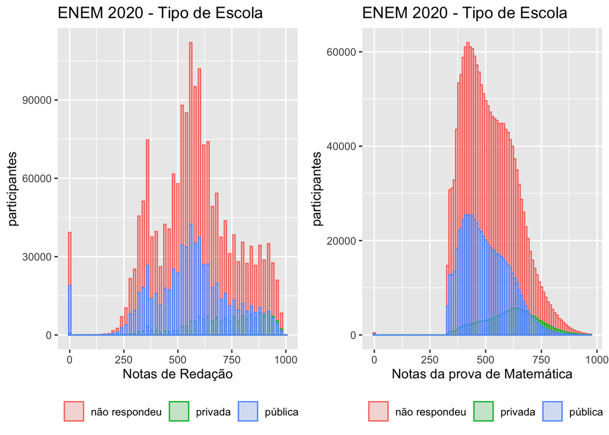

```r
notas_mat_hist <- ENEM_presents %>%
  ggplot() +
  aes(redacao,
      fill = TP_ESCOLA,
      colour = TP_ESCOLA) +
  labs(title = "ENEM 2020 - Tipo de Escola",
       x = "Notas de Redação",
       y = "participantes") +
  geom_histogram(binwidth = 10,
                 alpha = 0.2,
                 position = "identity") +
  theme(legend.position = "bottom",
        legend.title = element_blank())

notas_red_hist <- ENEM_presents %>%
  ggplot() +
  aes(matematica,
      fill = TP_ESCOLA,
      colour = TP_ESCOLA) +
  labs(title = "ENEM 2020 - Tipo de Escola",
       x = "Notas da prova de Matemática",
       y = "participantes") +
  geom_histogram(binwidth = 10,
                 alpha = 0.2,
                 position = "identity") +
  theme(legend.position = "bottom",
        legend.title = element_blank())

grid.arrange(notas_mat_hist, notas_red_hist, nrow = 1)
```

1774679 participantes não indicaram na inscrição o tipo de escola. Como há o interesse em comparar desempenho em Escolas Públicas e Escolas Privadas, os valores não declarados foram removidos do dataset

```r
table(ENEM_presents$TP_ESCOLA) -> escolas

escolas <- data.frame(escolas)
colnames(escolas) <- c("tipos", "total")

escolas %>%
  kableExtra::kbl(caption = "Tipos de Escolas") %>%
  kableExtra::kable_classic(full_width = F, html_font = "Cambria")
```

Tipos de Escolas

| tipos | total |
| --- | --- |
| não respondeu | 1774679 |
| privada | 163145 |
| pública | 650857 |

Removendo os dados dos participantes que não indicaram o tipo de escola:

```r
ENEM_presents <- ENEM_presents[ENEM_presents$TP_ESCOLA == "pública" |
                               ENEM_presents$TP_ESCOLA == "privada", ]
```

Refazendo os gráficos de comparação de desempenho nas provas de Redação e Matemática por tipo de escola, sem os dados dos participantes que não indicaram o tipo de escola:

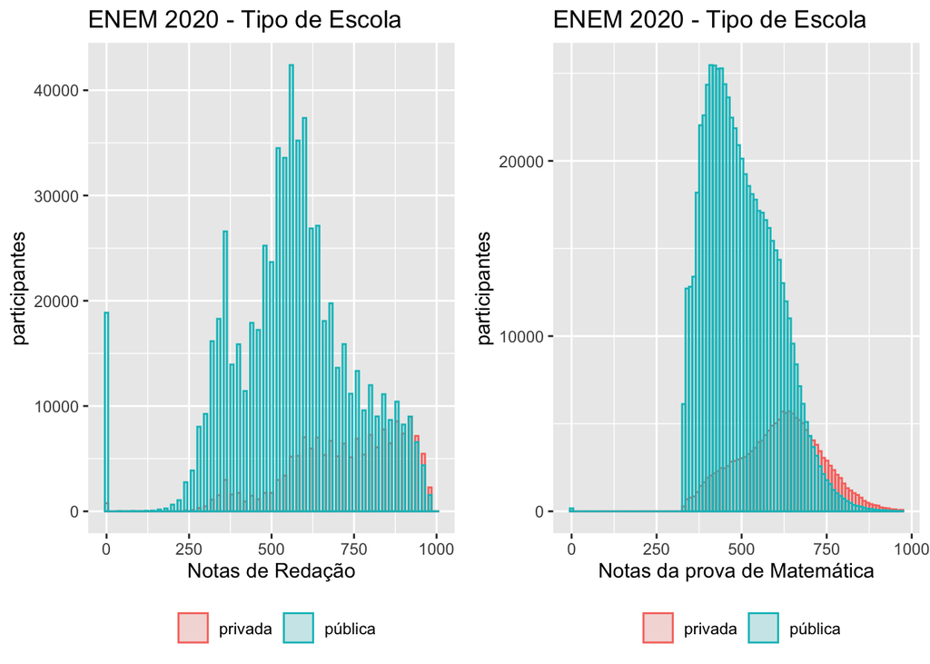

```r
notas_mat_hist <- ENEM_presents %>%
  ggplot() +
  aes(redacao,
      fill = TP_ESCOLA,
      colour = TP_ESCOLA) +
  labs(title = "ENEM 2020 - Tipo de Escola",
       x = "Notas de Redação",
       y = "participantes") +
  geom_histogram(binwidth = 10,
                 alpha = 0.2,
                 position = "identity") +
  theme(legend.position = "bottom",
        legend.title = element_blank())

notas_red_hist <- ENEM_presents %>%
  ggplot() +
  aes(matematica,
      fill = TP_ESCOLA,
      colour = TP_ESCOLA) +
  labs(title = "ENEM 2020 - Tipo de Escola",
       x = "Notas da prova de Matemática",
       y = "participantes") +
  geom_histogram(binwidth = 10,
                 alpha = 0.2,
                 position = "identity") +
  theme(legend.position = "bottom",
        legend.title = element_blank())

grid.arrange(notas_mat_hist, notas_red_hist, nrow = 1)
```

### 1.5.3 Prova de Matemática

#### 1.5.3.1 Comparativo do desempenho entre Escolas Públicas e Privadas:

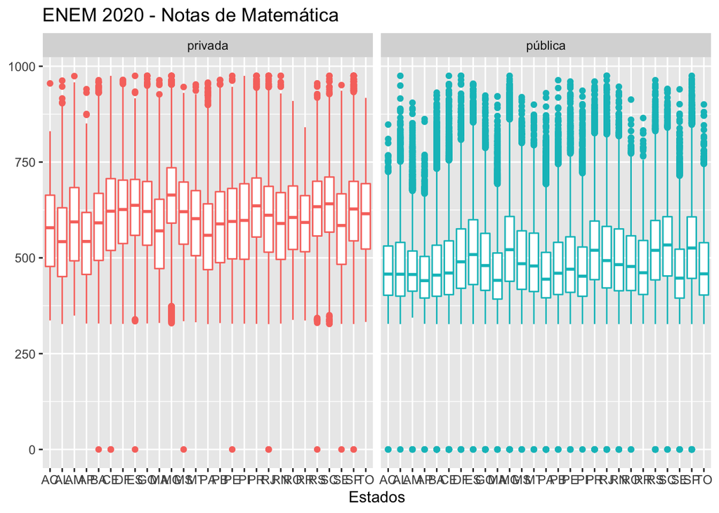

```r
ggplot(ENEM_presents, aes(x=SG_UF_PROVA, y=matematica, colour=TP_ESCOLA)) +
  geom_boxplot() +
  facet_wrap(~TP_ESCOLA) +
  labs(title = "ENEM 2020 - Notas de Matemática",
       x = "Estados",
       y = NULL) +
    theme(legend.position = "none")
```

**Comentário:** Visualmente, este gráfico mostra que o desempenho na Prova de Matemática dos alunos de escolas públicas, em todos os Estados foi inferior ao dos alunos de escolas privadas.

### 1.5.4 Prova de Redação

#### 1.5.4.1 Comparativo do desempenho entre Escolas Públicas e Privadas:

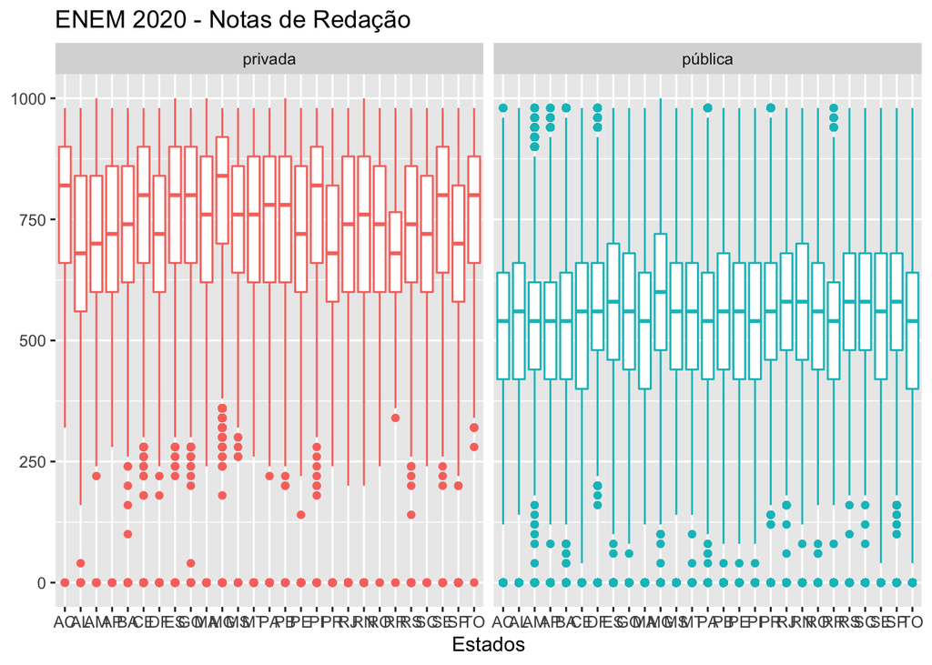

```r
ggplot(ENEM_presents, aes(x=SG_UF_PROVA, y=redacao, colour=TP_ESCOLA)) +
  geom_boxplot() +
  facet_wrap(~TP_ESCOLA) +
  labs(title = "ENEM 2020 - Notas de Redação",
       x = "Estados",
       y = NULL) +
    theme(legend.position = "none")
```

**Comentário:** O mesmo pode ser observado nas notas de Redação, ao ponto de notas mais altas na Redação, em alguns Estados, ser considerada um outlier. Vale a pena observar que a nota zero em Redação pode também ser considerada um outlier em todos os Estados, para ambas as escolas: públicas e privadas.

### 1.5.5 Comparativo das Escolas Públicas e Privadas para as Notas de Matemática e Redação

#### 1.5.5.1 Tabela

> Uso dos pacotes *psych* e *kableExtra*

```r
stat_publ <- describe(ENEM_presents[ENEM_presents$TP_ESCOLA == "pública" ,
                                    c('matematica', 'redacao')])
#                                    c('matematica', 'redacao')],
#         fast = TRUE)

stat_priv <- describe(ENEM_presents[ENEM_presents$TP_ESCOLA == "privada" ,
                                    c('matematica', 'redacao')])
#                                    c('matematica', 'redacao')],
#         fast=TRUE)


#stat_publ %>%
#  kbl(caption = "Escolas Públicas - Notas Matemática e Redação") %>%
#  kable_classic(full_width = F, html_font = "Cambria")

#stat_priv %>%
#  kbl(caption = "Escolas Privadas - Notas Matemática e Redação") %>%
#  kable_classic(full_width = F, html_font = "Cambria")

stat_publ <- data.frame(stat_publ)
stat_publ['aux'] <- c("Nota Matemática - Escola Pública", "Nota Redação - Escola Pública")
rownames(stat_publ) <- stat_publ$aux
stat_publ$aux <- NULL

stat_priv <- data.frame(stat_priv)
stat_priv['aux'] <- c("Nota Matemática - Escola Privada", "Nota Redação - Escola Privada")
rownames(stat_priv) <- stat_priv$aux
stat_priv$aux <- NULL

stat <- rbind(stat_priv, stat_publ)
stat$vars <- NULL

stat %>%
  kbl(caption = "Escolas Públicas e Privadas - Notas Matemática e Redação") %>%
  kable_styling(bootstrap_options = c("striped", "hover", "condensed", "responsive"),
                full_width = F)
```

Escolas Públicas e Privadas - Notas Matemática e Redação

|  | n | mean | sd | median | trimmed | mad | min | max | range | skew | kurtosis | se |
| --- | --- | --- | --- | --- | --- | --- | --- | --- | --- | --- | --- | --- |
| Nota Matemática - Escola Privada | 163145 | 610.6982 | 121.6520 | 617.9 | 611.3691 | 123.9454 | 0 | 975 | 975 | -0.0452102 | -0.3828662 | 0.3011844 |
| Nota Redação - Escola Privada | 163145 | 721.3609 | 173.7776 | 740.0 | 736.3804 | 177.9120 | 0 | 1000 | 1000 | -0.7597696 | 0.5387052 | 0.4302362 |
| Nota Matemática - Escola Pública | 650857 | 499.6495 | 103.6145 | 484.7 | 493.1608 | 112.3811 | 0 | 975 | 975 | 0.5407516 | -0.0554251 | 0.1284333 |
| Nota Redação - Escola Pública | 650857 | 558.8625 | 190.9134 | 560.0 | 561.4747 | 177.9120 | 0 | 1000 | 1000 | -0.3679314 | 0.6828121 | 0.2366430 |

#### 1.5.5.2 Gráfico

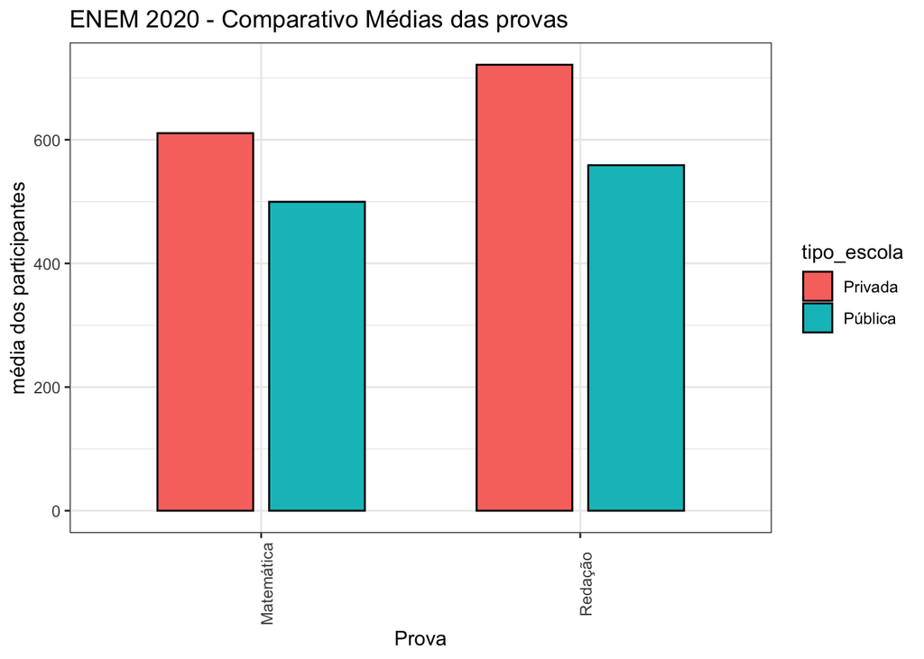

```r
stat_aux <- stat
stat_aux$prova <- rownames(stat)

stat_mat <- stat_aux[grep("Matemática", stat_aux$prova) , ]
stat_red <- stat_aux[grep("Redação", stat_aux$prova) , ]

stat_mat$tipo_prova <- "Matemática"
stat_red$tipo_prova <- "Redação"

stat_aux <- rbind(stat_mat, stat_red)

stat_pub <- stat_aux[grep("Pública", stat_aux$prova) , ]
stat_priv <- stat_aux[grep("Privada", stat_aux$prova) , ]

stat_pub$tipo_escola <- "Pública"
stat_priv$tipo_escola <- "Privada"

stat_aux <- rbind(stat_pub, stat_priv)

stat_aux %>%
  ggplot() +
  aes(x = tipo_prova,
      y = mean,
      fill = tipo_escola) +
  geom_col(position = position_dodge(0.7), width = 0.6, color = "black") +
  labs(title = "ENEM 2020 - Comparativo Médias das provas",
       x = "Prova",
       y = "média dos participantes") +
  theme(legend.position = "none") +
  theme_bw() +
  theme(axis.text.x = element_text(angle = 90))
```

## 1.6 Conclusão

Estes dados (desconsiderando as observações em que os participantes do ENEM não informaram o tipo de escola) demonstram que osalunos de escola pública tem notas menores que os alunos que estudaram em escolas privadas. As razões para este fato podem ter algumas explicações (ou suporte) nos dados socio-econômicos informados na inscrição, e presentes no dataset original. Futura expansão desta análise é possível para explorar outros anos do ENEM (para avaliar evolução), e dados socio-econômicos para procurar fatores que contribuem para este cenário.

## 1.7 Tempo de Execução

```r
TOTAL_DL <- c(TOTAL_DL$msg, TOTAL_DL$toc - TOTAL_DL$tic)
TOTAL_DW <- c(TOTAL_DW$msg, TOTAL_DW$toc - TOTAL_DW$tic)
TOTAL_AE <- c(TOTAL_AE$msg, TOTAL_AE$toc - TOTAL_AE$tic)
TOTAL <- c(TOTAL$msg, TOTAL$toc - TOTAL$tic)

tempos <- data.frame(c(TOTAL_DL[1], TOTAL_DL[2]),
                     c(TOTAL_DW[1], TOTAL_DW[2]),
                     c(TOTAL_AE[1], TOTAL_AE[2]),
                     c(TOTAL[1], TOTAL[2]))

tempos %>%
  purrr::set_names(as.character(slice(., 1))) %>%
  slice(-1) -> tempos

data.frame(t(tempos)) -> tempos

tempos$elapsed <- as.numeric(tempos$elapsed)

tempos %>%
  kable() %>%
  kable_styling(bootstrap_options = "striped",
                full_width = F,
                font_size = 12)
```

|  | elapsed |
| --- | --- |
| total_dataloading | 1065.207 |
| total_datawrangling | 44.472 |
| total_analiseexploratoria | 47.656 |
| total | 1157.403 |

```r
write.csv(tempos, "ambiente (teste) - T2 - Tempos.csv")
```